# Reproductible Research Assignment #1 August, 2015

peter lam

August 15, 2015

## Introduction

This assignment is to provide the class with a practice opportunity of practicing “Literate Statistical Programming”. The statistical analysis portion of this assignment is rather simple, but the main objective is to allow the class to practice the methodology behind “Literate Statiscal Programming”.

#### Requirement: Since grading is through peer assignment, it is required to output the code.

```r
knitr::opts_chunk$set(echo=TRUE, cache.path = 'DocumentName_cache/', fig.path='figure/')
```

#### Loading and preprocessing the data (Load into dtActivity)

```r
dtActivity <- read.csv("activity.csv",stringsAsFactors=FALSE)
summary(dtActivity)
```

```
##      steps            date              interval
##  Min.   :  0.00   Length:17568       Min.   :   0.0
##  1st Qu.:  0.00   Class :character   1st Qu.: 588.8
##  Median :  0.00   Mode  :character   Median :1177.5
##  Mean   : 37.38                      Mean   :1177.5
##  3rd Qu.: 12.00                      3rd Qu.:1766.2
##  Max.   :806.00                      Max.   :2355.0
##  NA's   :2304
```

#### What is mean total number of steps taken per day?

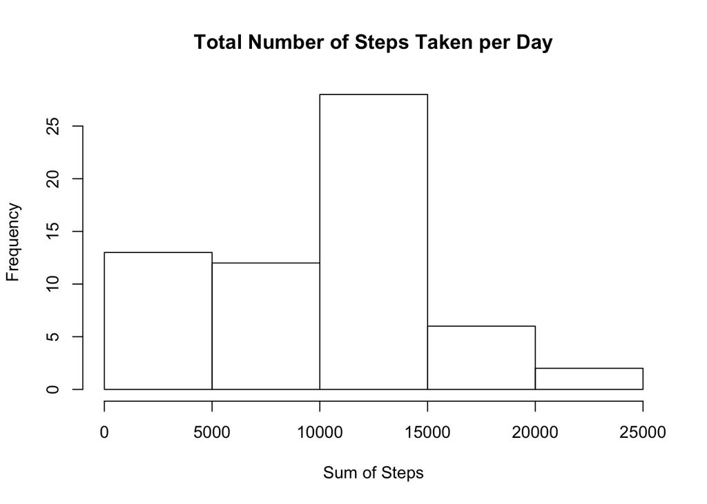

```r
vDailySteps <- tapply(dtActivity$steps, dtActivity$date, sum, na.rm=TRUE)
#vDailySteps

hist(vDailySteps, main = paste("Total Number of Steps Taken per Day"), xlab="Sum of Steps")
```

```r
#####Mean total number of steps taken per day:
mean(vDailySteps)
```

```
## [1] 9354.23
```

```r
#####Median total number of steps taken per day:
median(vDailySteps)
```

```
## [1] 10395
```

#### What is the average daily activity pattern?

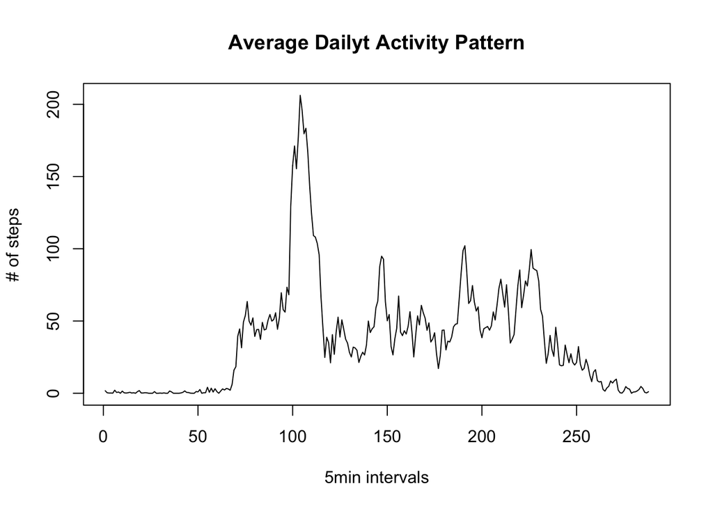

```r
vMeanSteps <- tapply(dtActivity$steps, dtActivity$interval, mean, na.rm=TRUE)
##vMeanSteps
plot(vMeanSteps, type="l", ylab="# of steps", xlab="5min intervals", main="Average Dailyt Activity Pattern")
```

##### Which 5-minute interval, on average across all the days in the dataset, contains the maximum number of steps?

```r
names(which.max(vMeanSteps))
```

```
## [1] "835"
```

#### Calculate and report the total number of missing values in the dataset (i.e. the total number of rows with NAs)

##### Number of missing “steps” values

```r
sum(is.na(dtActivity$steps))
```

```
## [1] 2304
```

##### Number of missing “date” values

```r
sum(is.na(dtActivity$date))
```

```
## [1] 0
```

##### Number of missing “interval” values

```r
sum(is.na(dtActivity$interval))
```

```
## [1] 0
```

#### Devise a strategy for filling in all of the missing values in the dataset. The strategy does not need to be sophisticated. For example, you could use the mean/median for that day, or the mean for that 5-minute interval, etc.

##### I am going to replace the NA with the average # of steps from the same interval. Reason for this approach is based on the assumption that the sample subject follows similar behavior each day; the missing values may be due to data capture failure or other technical reasons

#### Create a new dataset that is equal to the original dataset but with the missing data filled in.

```r
dtActivityFull <- dtActivity
nrow(dtActivity)
```

```
## [1] 17568
```

```r
nrow(vMeanSteps)
```

```
## [1] 288
```

```r
for (i in which(is.na(dtActivityFull))) {
  dtActivityFull[i,1] <- vMeanSteps[((i-1)%%288)+1]
}

sum(is.na(dtActivityFull$steps))
```

```
## [1] 0
```

#### Make a histogram of the total number of steps taken each day

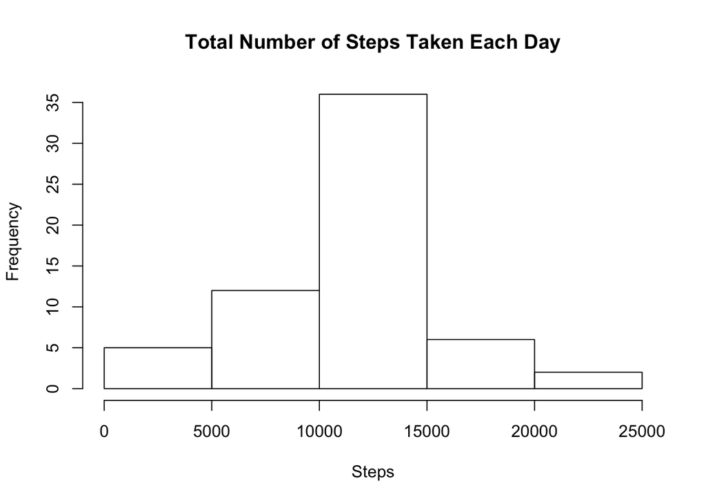

```r
hist(tapply(dtActivityFull$steps,dtActivityFull$date,sum), main = "Total Number of Steps Taken Each Day", xlab="Steps")
```

####Calculate and report the mean and median total number of steps taken per day.

```r
vDailyStepsFull <- tapply(dtActivityFull$steps, dtActivityFull$date, sum, na.rm=TRUE)

#####Mean total number of steps taken per day:
mean(vDailyStepsFull)
```

```
## [1] 10766.19
```

```r
#####Median total number of steps taken per day:
median(vDailyStepsFull)
```

```
## [1] 10766.19
```

#### Do these values differ from the estimates from the first part of the assignment? What is the impact of imputing missing data on the estimates of the total daily number of steps?

##### Yes, values changed as expected. Filling missing data with interval mean brings the mean and median same.

#### Create a new factor variable in the dataset with two levels – “weekday” and “weekend” indicating whether a given date is a weekday or weekend day.

```r
for (i in 1:nrow(dtActivityFull)) {
  sWhatDay <- weekdays(as.Date(dtActivityFull[i,2]))
  bWeekday <-ifelse(sWhatDay == "Sunday" | sWhatDay == "Saturday", "Weekend", "Weekday")
  dtActivityFull[i,4] <- bWeekday
}
colnames(dtActivityFull)[4] <- "WkDay"
```

#### Make a panel plot containing a time series plot (i.e. type = “l”) of the 5-minute interval (x-axis) and the average number of steps taken, averaged across all weekday days or weekend days (y-axis).

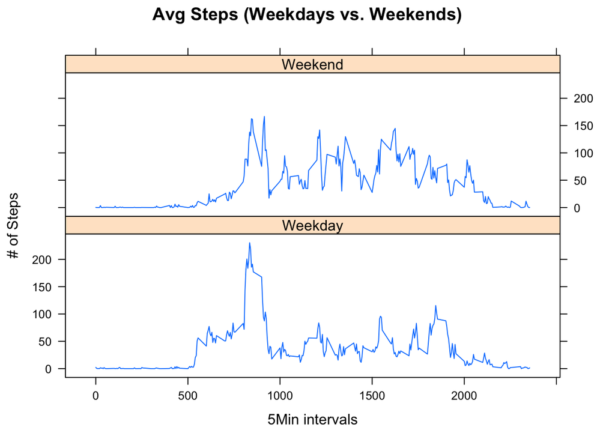

```r
dtActivityFullByWkDay <- aggregate(steps ~ interval + WkDay, data = dtActivityFull, FUN = "mean")
library(lattice)
xyplot(steps ~ interval | WkDay, data=dtActivityFullByWkDay, type="l",layout=c(1,2), xlab="5Min intervals", ylab="# of Steps", main="Avg Steps (Weekdays vs. Weekends)")
```

##### By observing the graph, we concluded the subject walked more during the weekday mornings, but the subject “out-walked” himself during weekend afternoons.